# Project Checkpoint 1

Marshall Graham

November 24, 2017

# 1

# Group members: Marshall, Zain, Colleen, Vishal

# 2

# b. Research questions:

1. How do bikeshare usage patterns vary depending on weather compared to buses?
2. Is there a correlation between proximity of a Niceride station to a bus stop and usage patterns of the Niceride station?

# ALTERNATIVE QUESTIONS:

-How do usage patterns of bikes and public transit vary from the norm on public holidays? -Is metro transit usage affected when the bikeshare closes down for the year (or is it just seasonal)?

# Datasets we will use

Data Source: metaweather Data Description: weather patterns for a certain day in Minneapolis Data Limitations: challenging to get at all 365 days with ease (without going through them one at a time) Data dimensions: 71x15 (for one day,)

# metroStops

Data source: Metro Transit Data description: Location of each bus stop (with site ID, city, latitude, longitude, etc.) Data limitations: bus stops that exist from 2014-2017 Data dimensions: 14,919 x 12

# metroRidership

Data source: Metro Transit Data description: Gives the day, if it’s a holiday, route number, route type, number of trips, and total number of riders on that day Data limitations: from January 2014- October 2017 Data dimensions: 131,078 x 10

# NicerideRidership

Data Source: Niceride 2016 data Data Description: Data contains information about trips: the start and end stations of each trip, the total time it took to complete the journey, and whether the passenger was a casual rider or a member. Data Limitations: Does not contain information about metro rides in December, January, February, and March. Only has 432283 rows with data in them, the rest are empty and this data has to be cleaned accordingly before use. Data dimensions: >432,284x8

# NiceRideStops

MinneapolisWeather Data Source: “http://www.dnr.state.mn.us/climate/twin_cities/listings.html”, the Department of Natural Resources has data going back to 1871 on the weather in Minneapolis/St. Paul. All data after 1938 is from MSP airport Data Description: Gives the date, max temperature, min temperature, amount of percpititaion, amount of snow, and amount of snow on the ground Data Limitations The specific data we’re using is the weather data between 2010 and 2017. It’s missing the average tempearture for a day, but the min and max are probably enough to work with Data dimensions: 2884 x 6

```r
library(tidyverse)
```

```r
library(ggplot2)
library(lubridate)
library(urltools)
library(jsonlite)
library(ggmap)
library(rvest)
library(geosphere)
```

Read in data on NiceRide, the bike share for the twin cities

```r
niceRide2016<-read_csv("Nice_ride_data_2016_season\\Nice_ride_data_2016_season\\Nice_ride_trip_history_2016_season.csv")
niceRideLocations<-read_csv("Nice_ride_data_2016_season\\Nice_ride_data_2016_season\\Nice_Ride_2016_Station_Locations.csv")
```

Read in data on MetroTransit

```r
metroStops<-read_csv("bus-stops-Oct-2017.csv")
metroRidership<-read_csv("ridership-route-day-Jan2014-Oct2017.csv")
```

```r
twinCitiesMap<-get_map(location="Minneapolis", zoom= 10)
#about 100 ft in degrees latitude
ft100<-.0002744
```

Limit the bus stops to only stops within a rectangle that encloses the bike stations

```r
minBikeLat<-min(niceRideLocations$Latitude)-ft100
maxBikeLat<-max(niceRideLocations$Latitude)+ft100

minBikeLong<-min(niceRideLocations$Longitude)-ft100
maxBikeLong<-max(niceRideLocations$Longitude)+ft100


#Only bus stops within square
metroStopsLimited<-metroStops%>%
   filter(site_longitude>minBikeLong&site_longitude<maxBikeLong)%>%
   filter(site_latitude>minBikeLat&site_latitude<maxBikeLat)
```

# Weather analysis

Read in data on weather for 2016

```r
#source: http://www.dnr.state.mn.us/climate/twin_cities/listings.html
#Had to copy and paste data from page into .txt file and read that in
MinneapolisWeather<-read_csv(file="Minneapolis Weather.txt", col_names = c("date", "maxTemp","minTemp","precip","snow","snowDepth"))
```

Clean up data

```r
MinneapolisWeather<-MinneapolisWeather%>%
   mutate(precip=as.double(replace(precip,precip=="T",0)))%>%
   mutate(snow=as.double(replace(snow,snow=="T",0)))%>%
   mutate(snowDepth=as.double(replace(snowDepth,snowDepth=="T",0)))
```

Show daily ridership from 2014-2017 overall

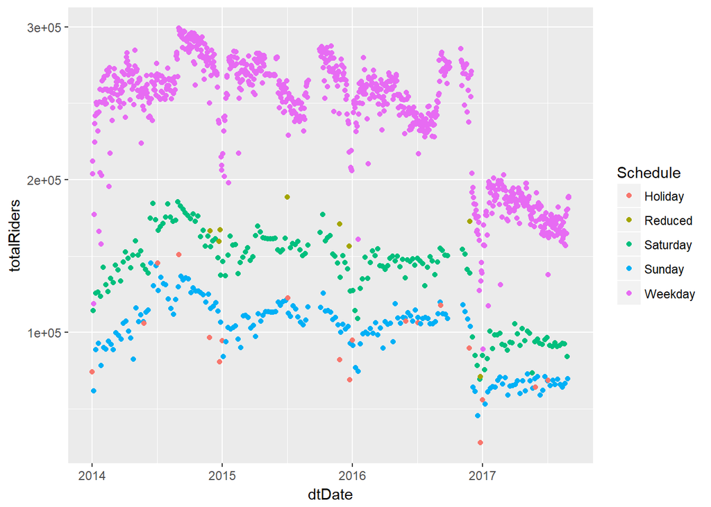

```r
#change date variable type to Date object
metroRidership<-metroRidership%>%
   mutate(dtDate=as.Date(dtDate))

#Calculate total number of riders for a given day, while still keeping data on what type of riding day it was (Holiday, weekday, etc.)
metroRidershipTotal<-metroRidership%>%
   group_by(dtDate)%>%
   summarize(totalRiders=sum(Total_Riders))%>%
   left_join(metroRidership, by="dtDate")%>%
   select(dtDate, totalRiders, Schedule)

#Show graph of total ridership for each day
ggplot(metroRidershipTotal, aes(x=dtDate, y=totalRiders, color=Schedule))+
   geom_point()
```

Show how divergence from daily mean effects ridership (only work with 2016 because thats time frame for nice ride data)

```r
#Add weather data to info on bus ridership
WeatherRiders<-metroRidership%>%
   left_join(MinneapolisWeather, by=c("dtDate"="date"))%>%
   filter(dtDate>="2016-01-01"&dtDate<="2016-12-31")#fix date object type


#Calculate the average temperature of a day over the seven years of weather data
#Should replace this with climate normals from NOAA
AvgDayTemp<-MinneapolisWeather%>%
   mutate(day=yday(date))%>%
   group_by(day)%>%
   summarize(dayTemp=sum((maxTemp+minTemp)/2)/n())

#Check that its 366 elements
nrow(AvgDayTemp)
```

```
## [1] 366
```

```r
#Calculate the difference between the average temperature of a day and the mean average temperature of that day over the seven years of weather data
WeatherRiders<-WeatherRiders%>%
   mutate(day=yday(dtDate))%>%
   left_join(AvgDayTemp, by="day")%>%
   mutate(tempDiff=(maxTemp+minTemp)/2-dayTemp)

WeatherRidersTotal<-WeatherRiders%>%
   mutate(day=as.factor(day), Route=as.factor(Route))%>%
   group_by(dtDate, tempDiff, dayTemp)%>%
   summarize(Total_Riders=sum(Total_Riders))

#Check that it worked
head(WeatherRidersTotal)
```

```
## # A tibble: 6 x 4
## # Groups:   dtDate, tempDiff [6]
##       dtDate tempDiff dayTemp Total_Riders
##       <date>    <dbl>   <dbl>        <dbl>
## 1 2016-01-01   9.5625 12.9375        94814
## 2 2016-01-02   9.8125 12.6875       127314
## 3 2016-01-03   9.4375 15.0625        91325
## 4 2016-01-04   6.8125 11.1875       244016
## 5 2016-01-05  16.7500  9.2500       249753
## 6 2016-01-06  17.1250 10.8750       251463
```

Visualization of how ridership is dependent on temperature of a day and how it depends on divergence from historical temperature on that day

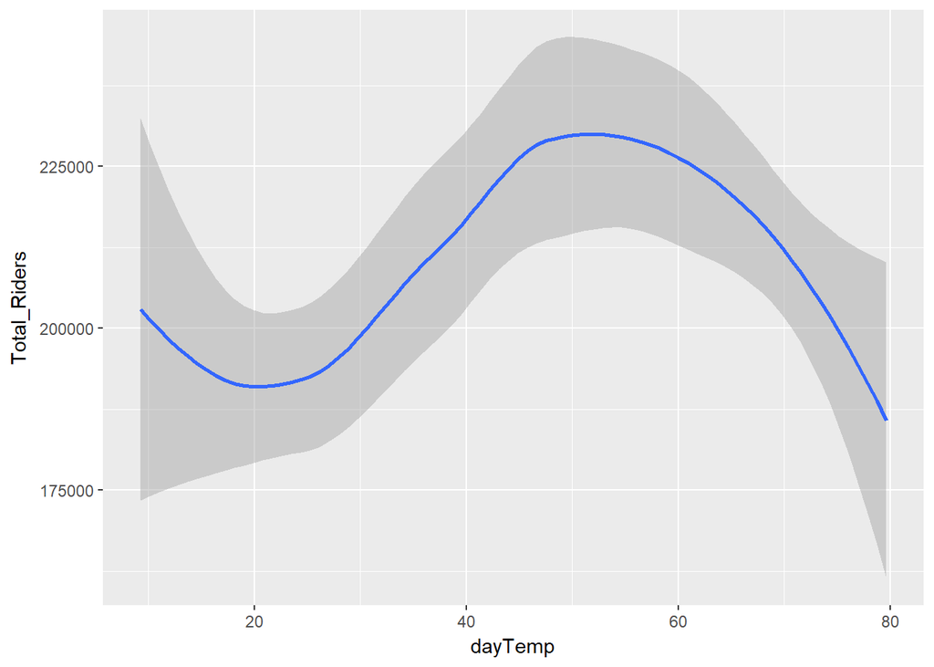

```r
#Group together all the riders on the different routes while keeping temp data

ggplot(WeatherRidersTotal, aes(x=dayTemp, y=Total_Riders))+
   geom_smooth()
```

We see that ridership does correlate wtih absolute temperature peaking at around 50 degrees F

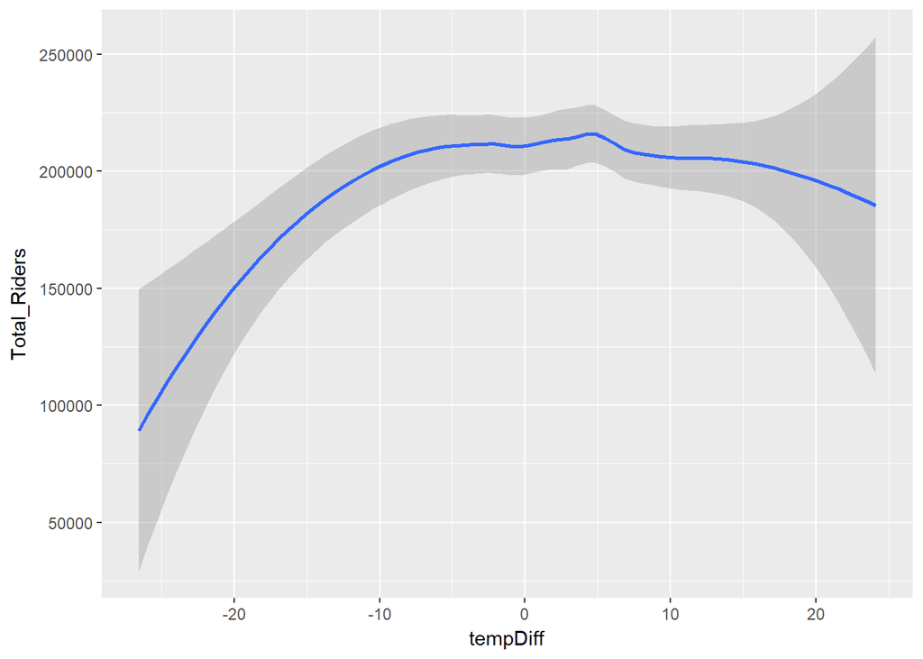

```r
ggplot(WeatherRidersTotal, aes(x=tempDiff, y=Total_Riders))+
   geom_smooth()
```

At very large temp differences ridership drops off, especially on colder days

## Doing same weather analysis with ridership

First get ridership of bikes by day

```r
#clean up date variable in data and total riders on that date
niceRideDay<-niceRide2016%>%
   mutate(startDate=niceRide2016$`Start date`)%>%
   select("startDate")%>%
   mutate(startDate=as.Date(startDate, "%m/%d/%Y"))%>%
   group_by(startDate)%>%
   summarize(numRiders=n())



#Check that it worked
head(niceRideDay)
```

```
## # A tibble: 6 x 2
##    startDate numRiders
##       <date>     <int>
## 1 2016-04-04       197
## 2 2016-04-05       284
## 3 2016-04-06       471
## 4 2016-04-07       446
## 5 2016-04-08       436
## 6 2016-04-09       415
```

```r
#Add weather data to NiceRide data, including divergence from normals
niceRideDay<-niceRideDay%>%
   left_join(MinneapolisWeather, by=c("startDate"="date"))%>%
   mutate(day=yday(startDate))%>%
   left_join(AvgDayTemp,by="day")%>%
   mutate(tempDiff=(maxTemp+minTemp)/2-dayTemp)

#Check that it worked
head(niceRideDay)
```

```
## # A tibble: 6 x 10
##    startDate numRiders maxTemp minTemp precip  snow snowDepth   day
##       <date>     <int>   <int>   <int>  <dbl> <dbl>     <dbl> <dbl>
## 1 2016-04-04       197      42      28   0.00   0.0         0    95
## 2 2016-04-05       284      37      28   0.07   0.0         0    96
## 3 2016-04-06       471      44      32   0.00   0.0         0    97
## 4 2016-04-07       446      43      33   0.04   0.0         0    98
## 5 2016-04-08       436      37      24   0.02   0.5         0    99
## 6 2016-04-09       415      43      20   0.00   0.0         0   100
## # ... with 2 more variables: dayTemp <dbl>, tempDiff <dbl>
```

Look at how NiceRide ridership correlates to temperature

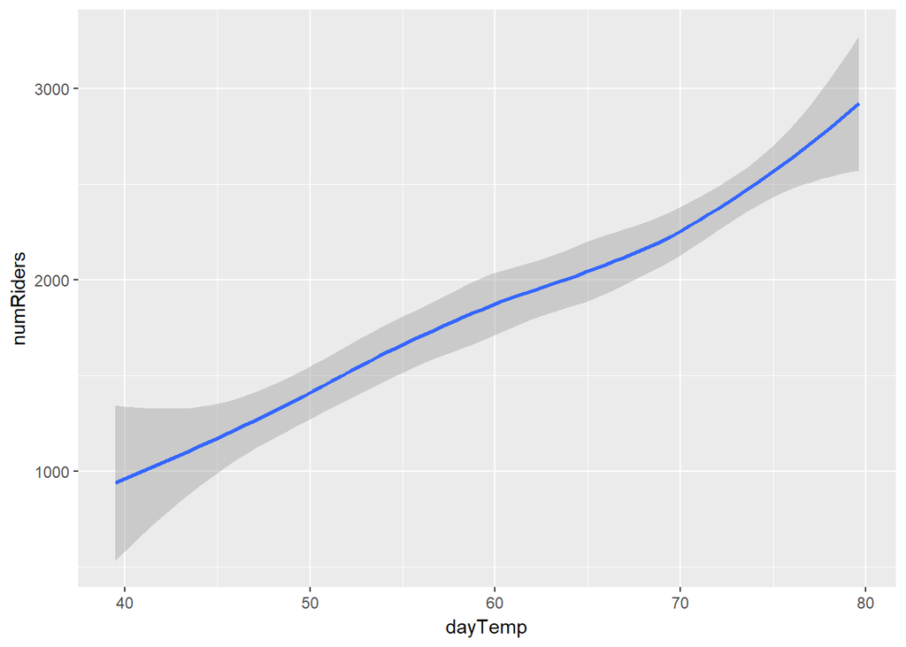

```r
ggplot(niceRideDay, aes(x=dayTemp, y=numRiders))+
   geom_smooth()
```

Unsuprisingly, more people ride bikes in warmer weather

Now look at how ridership correlates to departure from climate normals

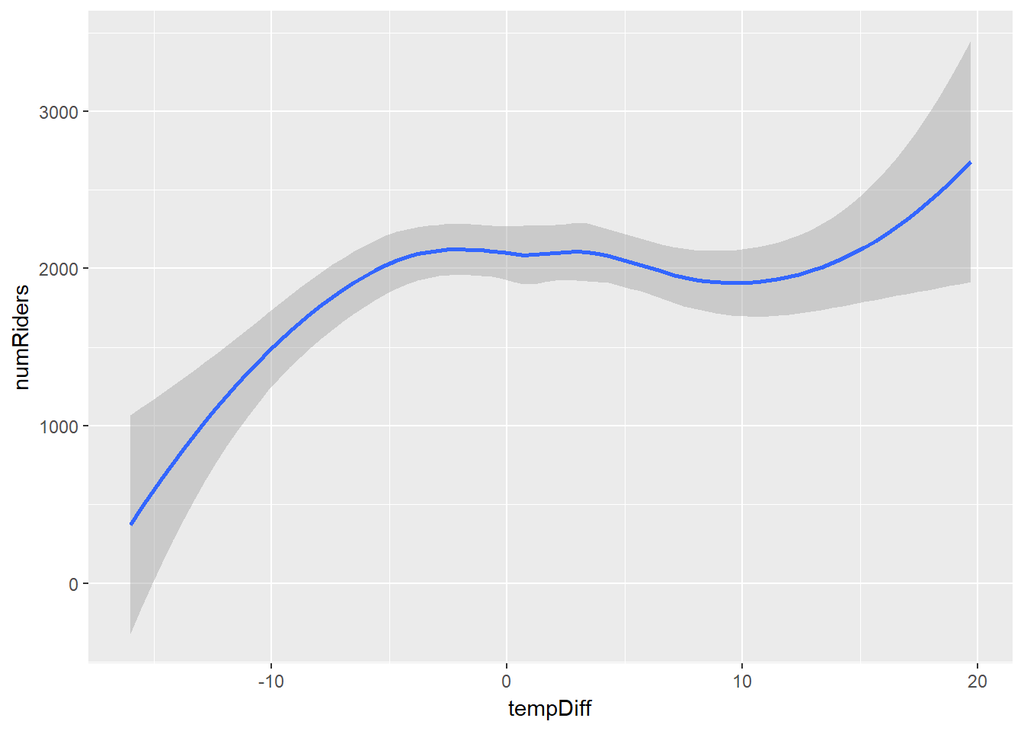

```r
ggplot(niceRideDay, aes(x=tempDiff, y=numRiders))+
   geom_smooth()
```

```r
minDist<-function(busLongs, busLats, bikeLong, bikeLat){
   busLongLat<-matrix(c(busLongs, busLats),ncol=2)
   curMin<-min(apply(busLongLat,FUN=distHaversine,MARGIN=1,p2=c(bikeLong, bikeLat)))
   return(curMin)
}

niceRideLocationsDist<-niceRideLocations%>%
   group_by(Terminal)%>%
   mutate(minDist = mapply(minDist, bikeLat=Latitude, bikeLong=Longitude, MoreArgs=list(busLongs=metroStopsLimited$site_longitude, busLats=metroStopsLimited$site_latitude)))
```

# Bus and bike station relation

```r
head(niceRide2016)
```

```
## # A tibble: 6 x 8
##      `Start date`           `Start station` `Start station number`
##             <chr>                     <chr>                  <chr>
## 1 11/6/2016 22:09               Willey Hall                  30195
## 2 11/6/2016 21:53              Sanford Hall                  30182
## 3 11/6/2016 21:52 11th Ave S & S 2nd Street                  30154
## 4 11/6/2016 21:52 11th Ave S & S 2nd Street                  30154
## 5 11/6/2016 21:52 11th Ave S & S 2nd Street                  30154
## 6 11/6/2016 21:52 11th Ave S & S 2nd Street                  30154
## # ... with 5 more variables: `End date` <chr>, `End station` <chr>, `End
## #   station number` <chr>, `Total duration (seconds)` <int>, `Account
## #   type` <chr>
```

```r
niceRideProximityRiders<-niceRide2016%>%
  left_join(niceRideLocationsDist, by=c("Start station"="Station"))%>%
  group_by(`Start station`, Latitude, Longitude, `Account type`)%>%
  summarize(total=n())%>%
  arrange(desc(total))%>%
  filter(!is.na(Latitude))
head(niceRideProximityRiders)
```

```
## # A tibble: 6 x 5
## # Groups:   Start station, Latitude, Longitude [6]
##                       `Start station` Latitude Longitude `Account type`
##                                 <chr>    <dbl>     <dbl>          <chr>
## 1 Washington Ave SE & Union Street SE 44.97394 -93.23210         Member
## 2            Lake Street & Knox Ave S 44.94850 -93.30521         Casual
## 3                       Coffman Union 44.97338 -93.23476         Member
## 4   Hennepin County Government Center 44.97660 -93.26670         Member
## 5            4th Street & 13th Ave SE 44.98102 -93.23746         Member
## 6                  Weisman Art Museum 44.97361 -93.23725         Member
## # ... with 1 more variables: total <int>
```

```r
niceRideProximityRiders2<-niceRide2016%>%
  left_join(niceRideLocationsDist, by=c("Start station"="Station"))%>%
  group_by(`Start station`, Latitude, Longitude)%>%
  summarize(total=n())%>%
  arrange(desc(total))%>%
  filter(!is.na(Latitude))
head(niceRideProximityRiders)
```

```
## # A tibble: 6 x 5
## # Groups:   Start station, Latitude, Longitude [6]
##                       `Start station` Latitude Longitude `Account type`
##                                 <chr>    <dbl>     <dbl>          <chr>
## 1 Washington Ave SE & Union Street SE 44.97394 -93.23210         Member
## 2            Lake Street & Knox Ave S 44.94850 -93.30521         Casual
## 3                       Coffman Union 44.97338 -93.23476         Member
## 4   Hennepin County Government Center 44.97660 -93.26670         Member
## 5            4th Street & 13th Ave SE 44.98102 -93.23746         Member
## 6                  Weisman Art Museum 44.97361 -93.23725         Member
## # ... with 1 more variables: total <int>
```

```r
twinCitiesMap<-get_map(location="Minneapolis", zoom= 13)
```

[figure not shown]

```r
ggmap(twinCitiesMap)+
   geom_point(data=niceRideProximityRiders2, aes(x=Longitude, y=Latitude, size=total, alpha=.5))
```

```r
niceRide2016dist<-niceRide2016%>%
   left_join(niceRideLocationsDist, by=c("Start station"="Station"))%>%
   group_by(Latitude, Longitude, minDist)%>%
   filter(!is.na(Latitude))

head(niceRide2016dist)
```

```
## # A tibble: 6 x 14
## # Groups:   Latitude, Longitude, minDist [3]
##      `Start date`           `Start station` `Start station number`
##             <chr>                     <chr>                  <chr>
## 1 11/6/2016 22:09               Willey Hall                  30195
## 2 11/6/2016 21:53              Sanford Hall                  30182
## 3 11/6/2016 21:52 11th Ave S & S 2nd Street                  30154
## 4 11/6/2016 21:52 11th Ave S & S 2nd Street                  30154
## 5 11/6/2016 21:52 11th Ave S & S 2nd Street                  30154
## 6 11/6/2016 21:52 11th Ave S & S 2nd Street                  30154
## # ... with 11 more variables: `End date` <chr>, `End station` <chr>, `End
## #   station number` <chr>, `Total duration (seconds)` <int>, `Account
## #   type` <chr>, Terminal <chr>, Latitude <dbl>, Longitude <dbl>, `Nb
## #   Docks` <int>, X6 <chr>, minDist <dbl>
```

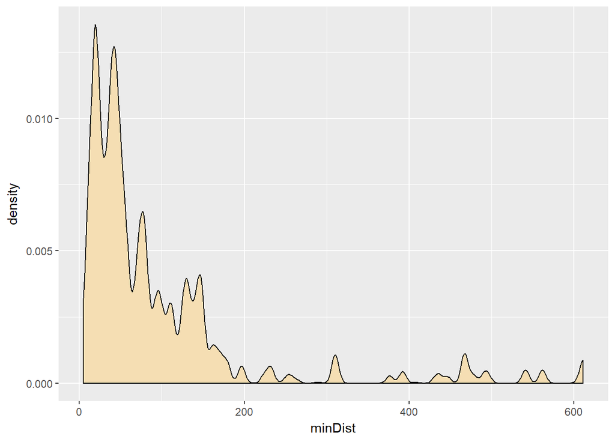

```r
ggplot(niceRide2016dist, aes(x=minDist))+
   geom_density(fill="wheat")
```

```r
#mindist= distance from bike station to closest bus station, in meters
```

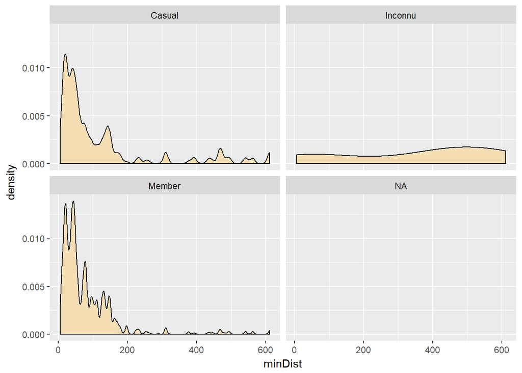

```r
niceRide2016Dist<-niceRide2016%>%
  left_join(niceRideLocationsDist, by=c("Start station"="Station"))

ggplot(niceRide2016Dist, aes(x=minDist))+
  geom_density(fill="wheat")+
  facet_wrap(~`Account type`)
```

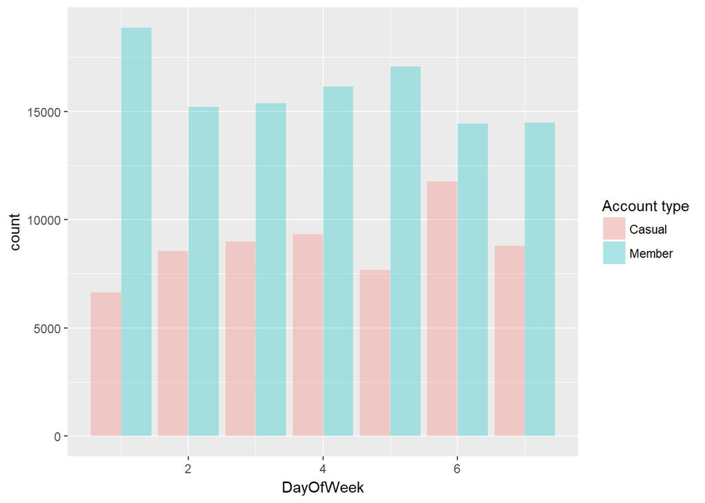

```r
niceRide2016<- niceRide2016 %>%
  mutate(`Start date`=as.Date(`Start date`))%>%
  mutate(DayOfWeek=wday(`Start date`))

ggplot(niceRide2016, aes(x= DayOfWeek)) + geom_bar(position = "dodge",aes(fill=`Account type`), alpha= 0.3)
```

# Group Contributions:

Colleen made some visualizations (we ended up using two of the ones she made), labeled/cleaned data relating to metrotransit, and wrangled some data for niceride, and helped brainstorm research questions.

Zain made some visualizations (two for the second research question), labelled/cleaned data relating to NiceRide 2016 data, wrangled some data for a nice ride visualization, and helped brainstorm research questions.

Marshall collected the data sets, ran the analysis on the weather data, worked on the calculations with the data sets, and set up the code sharing system

Vishal helped on working with distance between bikestations and bus-stations using haversine function(although we modified a lot to use in the actual code).